# Homework_4

### 3. Read https://www.tandfonline.com/doi/full/10.1080/10691898.2018.1434342 for information about the [SBA Business Loans Data](https://uofi.box.com/shared/static/vi37omgitiaa2yyplrom779qvwk1g14x.csv) and do the following:

1. create a visualization (plot) of at least two variables (excluding ID or label variables) using this dataset

[figure not shown]

```r
loan_data<-read.csv("SBAnational.csv")
loan_length<-loan_data$Term
loan_amount<-as.numeric(loan_data$DisbursementGross)
amount_to_term <- loan_amount/loan_length
years<-loan_data$ApprovalFY
plot(years,jitter(amount_to_term), main = "Average monthly loan payment over time", xlab = "Years", ylab="$", col = "lightblue2")
```

2. explain what is good and what is bad about the visualization

The graph makes it easy to see how the bank makes loan decisions over time. The amount the bank disburses divided by the term length indicates how risky the investment is. Making this a ratio essentially standardizes all the laons on a similar scale. The higher the ratio, the riskier the investment, because they have less time to pay a larger amount per month. The graph allows us to see these riskier outliers, as well as a loan schedule given that the axis is time series data. We can also do some forecasting with this data as well, given some trend analysis.

What’s bad about the graph is that most of the data is within the lower parts of the y axis, so the graph gives an impression about the bank data which is not necessarily true.

3. show a substantially improved visualization

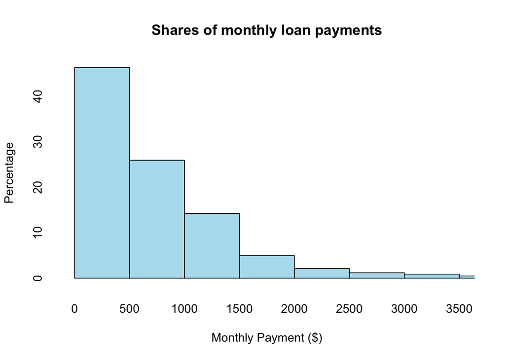

```r
years<-as.numeric(years)
ok <- hist(amount_to_term,years,breaks = 200,plot=F)
ok$density <- ok$counts/sum(ok$counts)*100
plot(ok,freq = F,col="lightblue2",xlim=c(0,3500),main = "Shares of monthly loan payments",xlab="Monthly Payment ($)",ylab = "Percentage",axes = F)
axis(1,col = NA, col.ticks = 0)
axis(2,col=NA,col.ticks =0)
```

4. describe the improvement and why the improved plot in **part 3c** helps the reader or viewer more than the original plot in **part 3a**.

This graph makes it apparant, as opposed to the previous, that a majority of loans to small businesses have payments of 1000 or less. The outlines around the plot as well as axis lines and ticks are removed to get rid of clutter.

### 4. Read https://www.tandfonline.com/doi/full/10.1080/10691898.2018.1434342 for information about the [SBA Business Loans Data](https://uofi.box.com/shared/static/vi37omgitiaa2yyplrom779qvwk1g14x.csv) and do the following:

1. create a table of descriptive statistics of your choice

```r
mat <- summary(amount_to_term)
mat
```

```
##      Min.   1st Qu.    Median      Mean   3rd Qu.      Max.
##    0.0033  251.0633  575.2738       Inf 1078.8042       Inf
```

```r
median <- quantile(amount_to_term, probs=c(.5))
rounded <- as.character(round(median, digits = 0))
```

2. redo the plot in **part 3c** but add one of the descriptive statistics from **part 4a** to the plot

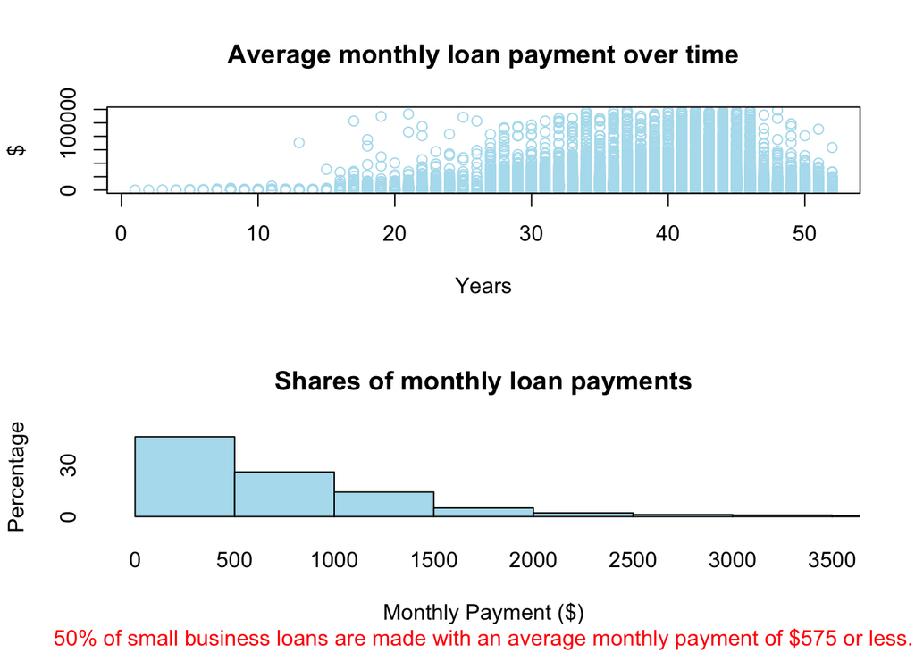

```r
par(mfrow = c(2,1))
plot(as.character(years),jitter(amount_to_term), main = "Average monthly loan payment over time", xlab = "Years", ylab="$", col = "lightblue2")
#I wanted to show both plots side by side, but it doesn't handle well.
ok <- hist(amount_to_term,years,breaks = 200,plot=F)
ok$density <- ok$counts/sum(ok$counts)*100
plot(ok,freq = F,col="lightblue2",xlim=c(0,3500),main = "Shares of monthly loan payments",xlab="Monthly Payment ($)",ylab = "Percentage",axes = F)
axis(1,col = NA, col.ticks = 0)
axis(2,col=NA,col.ticks =0)
string <- paste("50% of small business loans are made with an average monthly payment of $",rounded," or less.",sep="")
mtext(text = string , side = 1, line = 4,col = 2)
```

3. write a brief explanatory narrative of the visualization in **part 4b**. In your explanation, be convincing and persuasive about your visualization. Attempt to highlight why this visualization is crucial to your imaginary supervisor.

From this graph we can see that 50% of small businesses have loans that make, on average, $575 in loan payments or less per month. On the other hand, we can see that the 50% of businesses who make payments above this are highly spread in terms of credit risk. In fact, this spread is upwards of about 100,000 dollars in average monthly payments. This tells us that most small businesses have not taken out large loans to expand their operations, which opens up a large market for small business consulting. We could specialize in finding ways to expand small businesses and leverage the untapped potential of bank financing, charging on the increased profits of the business, or perhaps asking for equity in exchange for our consulting services.